# lab7-jc-spect-readout

[figure not shown]

### Jaynes-Cummings Hamiltonian

For qubits, we can describe the dynamics of the qubit with the **Pauli Matrices**

$$ \sigma^x = \begin{pmatrix} 0 & 1 \\ 1 & 0 \end{pmatrix} \qquad \sigma^y = \begin{pmatrix} 0 & -i \\ i & 0 \end{pmatrix} \qquad \sigma^z = \begin{pmatrix} 1 & 0 \\ 0 & -1 \end{pmatrix} \qquad $$

The Pauli matrices let us define raising and lowering operators

$$ \sigma^+ = \frac{1}{2}( \sigma^x - i\sigma^y) \qquad {\rm and} \qquad \sigma^- = \frac{1}{2}( \sigma^x + i\sigma^y)$$

They raise and lower qubit states

$$ \sigma^+ |0\rangle = |1\rangle \qquad \sigma^+ |1\rangle = 0 \qquad {\rm and} \qquad \sigma^-|1\rangle = |0\rangle \qquad \sigma^-|0\rangle = 0$$

The interaction between qubit and resonator is descibed by the **Jaynes-Cummings Hamiltonian**

$$ H_{\rm JC}^{\rm (RWA)}/\hbar = \underbrace{\omega_r a^\dagger a}_\text{resonator} - \overbrace{\frac{1}{2} \omega_q \sigma_z}^\text{qubit} + \underbrace{g(a^\dagger \sigma^- + a \sigma^+)}_\text{dipole interaction}. $$

In order to understand it, we must *block-diagonalize* it using the *Schrieffer-Wolff transformation*.

## The Schrieffer-Wolff Transformation

You have a diagonalized Hamiltonian plus a perturbation $$ H \quad = \quad \underbrace{\begin{pmatrix} \Box & & & & & & \\ & \Box & & & & & \\ & & \Box & & & & \\ & & & \Box & & & \\ & & & & \Box & & \\ & & & & & \Box & \\ & & & & & & \Box \end{pmatrix}}_\text{diagonal} \quad + \quad \underbrace{\begin{pmatrix} \times & \times & \times & \times & \cdot & \cdot & \cdot \\ \times & \times & \times & \times & \cdot & \cdot & \cdot \\ \times & \times & \times & \times & \cdot & \cdot & \cdot \\ \times & \times & \times & \times & \cdot & \cdot & \cdot \\ \cdot & \cdot & \cdot & \cdot & \times & \times & \times \\ \cdot & \cdot & \cdot & \cdot & \times & \times & \times \\ \cdot & \cdot & \cdot & \cdot & \times & \times & \times \end{pmatrix}}_\text{perturbation} $$

Split the perturbation into *block diagonal* and *block off-diagonal* parts so that $H = H_0 + H_1 + H_2$ $$ H \quad = \quad \underbrace{\begin{pmatrix} \Box & & & & & & \\ & \Box & & & & & \\ & & \Box & & & & \\ & & & \Box & & & \\ & & & & \Box & & \\ & & & & & \Box & \\ & & & & & & \Box \end{pmatrix}}_\text{diagonal} \quad + \quad \underbrace{\begin{pmatrix} \times & \times & \times & \times & & & \\ \times & \times & \times & \times & & & \\ \times & \times & \times & \times & & & \\ \times & \times & \times & \times & & & \\ & & & & \times & \times & \times \\ & & & & \times & \times & \times \\ & & & & \times & \times & \times \end{pmatrix}}_\text{block diagonal} \quad + \quad \underbrace{\begin{pmatrix} & & & & \cdot & \cdot & \cdot \\ & & & & \cdot & \cdot & \cdot \\ & & & & \cdot & \cdot & \cdot \\ & & & & \cdot & \cdot & \cdot \\ \cdot & \cdot & \cdot & \cdot & & & \\ \cdot & \cdot & \cdot & \cdot & & & \\ \cdot & \cdot & \cdot & \cdot & & & \end{pmatrix}}_\text{block non-diagonal} $$

## The Schrieffer-Wolff Transformation

We seek an anti-hermitian, block off-diagonal operator $S$ such that

$$ H_{\rm eff} = e^{iS} H e^{-iS} = \sum_{m=0}^\infty \frac{1}{m!} \left[H, S\right]^{(m)} \qquad {\rm with} \qquad \left[H,S\right]^{(m)} = \left[\left[H,S\right]^{(m-1)},S\right] \quad {\rm and} \quad \left[H,S\right]^{(0)} = H $$

is the generalized commutator

Taking $H_1+H_2$ as a perturbation on the diagonal $H_0$ and $S$ as a Taylor expansion

$$ H = H_0 + \lambda(H_1 + H_2) \qquad S = \sum_{m=1}^\infty \lambda^m S^{(m)} $$

to keep track of the order $\lambda$

Then

$$ H_{\rm eff} = H_0 + \lambda (H_1+H_2) + \left[H_0 + \lambda(H_1+H_2), \lambda S^{(1)}\right] + \frac{1}{2} \left[ \left[ H_0 + \lambda(H_1+H_2), \lambda S^{(1)}\right], \lambda S^{(1)}\right] + \left[H_0 + \lambda(H_1+H_2), \lambda^2 S^{(2)}\right] + \ldots \\ \approx H_0 + \lambda \left( H_1 + H_2 + \left[H_0, S^{(1)}\right] \right) + \lambda^2 \left( \left[H_1+H_2, S^{(1)}\right] + \frac{1}{2} \left[ \left[H_0, S^{(1)}\right], S^{(1)}\right] + \left[H_0, S^{(2)}\right]\right) $$

up to second order in $\lambda$

## The Schrieffer-Wolff Transformation

The transformation eliminates the block off-diagonal part of $H_{\rm eff}$,

$$ H_{\rm eff}^{\rm off-diag} = \sum_{m=0}^\infty \frac{1}{(2m+1)!} [H_0 + H_1, S]^{(2m+1)} + \sum_{m=0}^\infty \frac{1}{(2m)!} [H_2, S]^{(2m)} \equiv 0, $$

to each order of $\lambda$

Expanding

$$ H_{\rm eff}^{\rm off-diag} = \left[ H_0 + \lambda H_1, \lambda S^{(1)} \right]+\lambda H_2 + \left[H_0 + \lambda H_1, \lambda^2 S^{(2)}\right] + \frac{1}{3!} \left[ H_0+\lambda H_1, \lambda S^{(1)}\right]^{(3)} + \frac{1}{2!} \left[ \lambda H_2, \lambda S^{(1)}\right]^{(2)} \\ = \lambda \left( \left[ H_0, S^{(1)} \right] + H_2 \right) + \lambda^2 \left( \left[H_1, S^{(1)} \right] + \left[H_0, S^{(2)}\right]\right) + \ldots $$

Going to second order yields

$$ \left[ H_0, S^{(1)} \right] = -H_2 \qquad \left[ H_0, S^{(2)} \right] = -\left[H_1, S^{(1)}\right] $$

## The Schrieffer-Wolff Transformation

$$ H_{\rm eff} = H_0 + \lambda \left( H_1 + H_2 + \left[H_0, S^{(1)}\right] \right) + \lambda^2 \left( \left[H_1+H_2, S^{(1)}\right] + \frac{1}{2} \left[ \left[H_0, S^{(1)},\right] S^{(1)}\right] + \left[H_0, S^{(2)}\right]\right) $$

Substituting the equations needed to cancel the block off-diagonal terms and letting $\lambda \to 1$

$$ H_{\rm eff} = H_0 + H_1 + \frac{1}{2} \left[ H_2, S^{(1)} \right] $$

Now we only need to find $S^{(1)}$ for a second-order correction!

The recent manuscript [A Systematic Method for Schrieffer-Wolff Transformation and Its Generalizations](http://www.arxiv.org/abs/2004.06534) systematically provides the ansatz by calculating

$$\eta = [H_0, H_2] $$

and set the coefficients such that

$$ [H_0, \eta] = H_2$$

which means $\eta$ is the same as $S^{(1)}$ by uniqueness

## S-W Tranformation of the J-C Hamiltonain

For ease of tedious calculations, we will use the Python package [`sympy`](http://www.sympy.org) for symbolic mathematics.

```python
# import SymPy and define symbols
import sympy as sp
sp.init_printing(use_unicode=True)
wr = sp.Symbol('\omega_r') # resonator frequency
wq = sp.Symbol('\omega_q') # qubit frequency
g = sp.Symbol('g', real=True) # vacuum Rabi coupling
Delta = sp.Symbol('Delta', real=True) # wr - wq; defined later
```

```python
# import operator relations and define them
from sympy.physics.quantum.boson import BosonOp
a = BosonOp('a') # resonator photon annihilation operator
from sympy.physics.quantum import pauli, Dagger, Commutator
from sympy.physics.quantum.operatorordering import normal_ordered_form
```

## S-W Tranformation of the J-C Hamiltonian

```python
# Pauli matrices
sx = pauli.SigmaX()
sy = pauli.SigmaY()
sz = pauli.SigmaZ()

# qubit raising and lowering operators
splus = pauli.SigmaPlus()
sminus = pauli.SigmaMinus()
```

```python
# define J-C Hamiltonian in terms of diagonal and non-block diagonal terms
H0 = wr*Dagger(a)*a - (1/2)*wq*sz;
H1 = 0
H2 = g*(Dagger(a)*sminus + a*splus);
HJC = H0 + H1 + H2; HJC # print
```

$\displaystyle - 0.5 \omega_q {\sigma_z} + \omega_r {{a}^\dagger} {a} + g \left({{a}^\dagger} {\sigma_-} + {a} {\sigma_+}\right)$

## S-W Tranformation of the J-C Hamiltonian

```python
# using the above method for finding the ansatz
eta = Commutator(H0, H2); eta
```

$\displaystyle - g \left[{{a}^\dagger} {\sigma_-} + {a} {\sigma_+},- 0.5 \omega_q {\sigma_z} + \omega_r {{a}^\dagger} {a}\right]$

We will need to used the methods `doit()`, `expand`, `normal_ordered_form`, and `qsimplify_pauli`

```python
pauli.qsimplify_pauli(normal_ordered_form(eta.doit().expand()))
```

$\displaystyle 1.0 \omega_q g {{a}^\dagger} {\sigma_-} - 1.0 \omega_q g {a} {\sigma_+} + \omega_r g {{a}^\dagger} {\sigma_-} - \omega_r g {a} {\sigma_+}$

## S-W Tranformation of the J-C Hamiltonian

Now take $A$ and $B$ as the coefficients of $a^\dagger \sigma_-$ and $a\sigma_+$, respectively. Then the commutator

```python
A = sp.Symbol('A')
B = sp.Symbol('B')
eta = A * Dagger(a) * sminus - B * a * splus;
pauli.qsimplify_pauli(normal_ordered_form(Commutator(H0, eta).doit().expand()))
```

$\displaystyle 1.0 A \omega_q {{a}^\dagger} {\sigma_-} + A \omega_r {{a}^\dagger} {\sigma_-} + 1.0 B \omega_q {a} {\sigma_+} + B \omega_r {a} {\sigma_+}$

This expression should be equal to $H_2$

```python
H2
```

$\displaystyle g \left({{a}^\dagger} {\sigma_-} + {a} {\sigma_+}\right)$

## S-W Tranformation of the J-C Hamiltonian

```python
S1 = eta.subs(A, g/Delta)
S1 = S1.subs(B, g/Delta); S1.factor()
```

$\displaystyle \frac{g \left({{a}^\dagger} {\sigma_-} - {a} {\sigma_+}\right)}{\Delta}$

Then we can calculate the effective second order correction to $H_0$

```python
Heff = H0 + H1 + 0.5*pauli.qsimplify_pauli(normal_ordered_form(Commutator(H2, S1).doit().expand())).simplify(); Heff
```

$\displaystyle - 0.5 \omega_q {\sigma_z} + \omega_r {{a}^\dagger} {a} + \frac{0.5 g^{2} \left(1 + 2 {{a}^\dagger} {a} {\sigma_z} + {\sigma_z}\right)}{\Delta}$

This is typically written as $$ H_{\rm eff} = \left(\omega_r + \frac{g^2}{\Delta}\sigma_z\right)a^\dagger a - \frac{1}{2}\left(\omega_q -\frac{g^2}{\Delta}\right) \sigma_z $$ which shows a state-dependent shift by $\chi \equiv g^2/\Delta$ of the resonator frequency called the *ac Stark shift* and a shift in qubit frequency due to quantum vacuum fluctuations called the *Lamb shift*.

## Qiskit Pulse - Spectroscopy

### Import Necessary Libraries

```python
from qiskit.tools.jupyter import *
from qiskit import IBMQ
IBMQ.load_account()
provider = IBMQ.get_provider(hub='ibm-q', group='open', project='main')
backend = provider.get_backend('ibmq_armonk')
```

```
ibmqfactory.load_account:WARNING:2020-07-27 14:44:14,221: Credentials are already in use. The existing account in the session will be replaced.
```

### Verify Backend is Pulse-enabled

```python
backend_config = backend.configuration()
assert backend_config.open_pulse, "Backend doesn't support Pulse"

dt = backend_config.dt
print(f"Sampling time: {dt*1e9} ns")
backend_defaults = backend.defaults()
```

```
Sampling time: 0.2222222222222222 ns
```

## Qiskit Pulse - Spectroscopy

```python
import numpy as np

# unit conversion factors -> all backend properties returned in SI (Hz, sec, etc)
GHz = 1.0e9 # Gigahertz
MHz = 1.0e6 # Megahertz
kHz = 1.0e3
us = 1.0e-6 # Microseconds
ns = 1.0e-9 # Nanoseconds

# We will find the qubit frequency for the following qubit.
qubit = 0

# The sweep will be centered around the estimated qubit frequency.
center_frequency_Hz = backend_defaults.qubit_freq_est[qubit]        # The default frequency is given in Hz
                                                                    # warning: this will change in a future release
print(f"Qubit {qubit} has an estimated frequency of {center_frequency_Hz / GHz} GHz.")
```

```
Qubit 0 has an estimated frequency of 4.9744440960448815 GHz.
```

## Qiskit Pulse - Spectroscopy

```python
# scale factor to remove factors of 10 from the data
scale_factor = 1e-14
# We will sweep 40 MHz around the estimated frequency
frequency_span_Hz = 40 * MHz
# in steps of 1 MHz.
frequency_step_Hz = 1 * MHz
# We will sweep 20 MHz above and 20 MHz below the estimated frequency
frequency_min = center_frequency_Hz - frequency_span_Hz / 2
frequency_max = center_frequency_Hz + frequency_span_Hz / 2
# Construct an np array of the frequencies for our experiment
frequencies_GHz = np.arange(frequency_min / GHz,
                            frequency_max / GHz,
                            frequency_step_Hz / GHz)

print(f"The sweep will go from {frequency_min / GHz} GHz to {frequency_max / GHz} GHz \
in steps of {frequency_step_Hz / MHz} MHz.")
```

```
The sweep will go from 4.954444096044882 GHz to 4.994444096044882 GHz in steps of 1.0 MHz.
```

## Qiskit Pulse - Spectroscopy

```python
from qiskit import pulse            # This is where we access all of our Pulse features!

inst_sched_map = backend_defaults.instruction_schedule_map
measure = inst_sched_map.get('measure', qubits=[qubit])
x_pulse = inst_sched_map.get('x', qubits=[qubit])

### Collect the necessary channels
drive_chan = pulse.DriveChannel(qubit)
meas_chan = pulse.MeasureChannel(qubit)
acq_chan = pulse.AcquireChannel(qubit)
```

```python
# Create the base schedule
# Start with drive pulse acting on the drive channel
schedule = pulse.Schedule(name='Frequency sweep')
schedule += x_pulse
# The left shift `<<` is special syntax meaning to shift the start time of the schedule by some duration
schedule += measure << schedule.duration

# Create the frequency settings for the sweep (MUST BE IN HZ)
frequencies_Hz = frequencies_GHz*GHz
schedule_frequencies = [{drive_chan: freq} for freq in frequencies_Hz]
```

## Qiskit Pulse - Spectroscopy

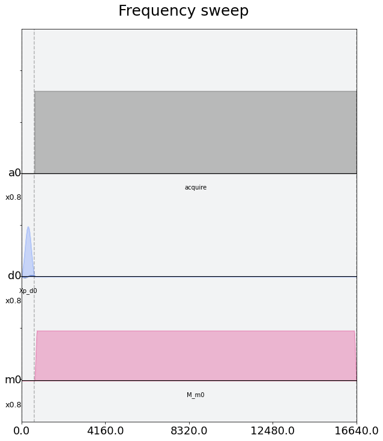

```python
schedule.draw(label=True, scaling=0.8)
```

## Qiskit Pulse - Spectroscopy

```python
from qiskit import assemble
frequency_sweep_program = assemble(schedule,
                                   backend=backend,
                                   meas_level=1,
                                   meas_return='avg',
                                   shots=1024,
                                   schedule_los=schedule_frequencies)
```

```python
# RUN the job on a real device
#job = backend.run(rabi_experiment_program)
#print(job.job_id())
#from qiskit.tools.monitor import job_monitor
#job_monitor(job)

# OR retreive result from previous run
job = backend.retrieve_job('5ef3b081fbc24b001275b03b')
```

## Qiskit Pulse - Spectroscopy

```python
frequency_sweep_results = job.result()
```

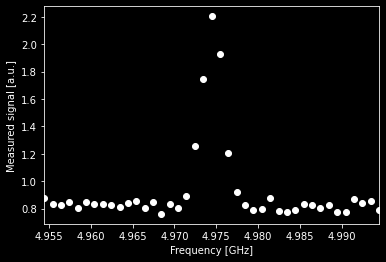

```python
import matplotlib.pyplot as plt
plt.style.use('dark_background')

sweep_values = []
for i in range(len(frequency_sweep_results.results)):
    # Get the results from the ith experiment
    res = frequency_sweep_results.get_memory(i)*scale_factor
    # Get the results for `qubit` from this experiment
    sweep_values.append(res[qubit])

plt.scatter(frequencies_GHz, np.real(sweep_values), color='white') # plot real part of sweep values
plt.xlim([min(frequencies_GHz), max(frequencies_GHz)])
plt.xlabel("Frequency [GHz]")
plt.ylabel("Measured signal [a.u.]")
plt.show()
```

## Qiskit Pulse - Spectroscopy

```python
from scipy.optimize import curve_fit

def fit_function(x_values, y_values, function, init_params):
    fitparams, conv = curve_fit(function, x_values, y_values, init_params)
    y_fit = function(x_values, *fitparams)

    return fitparams, y_fit
```

```python
fit_params, y_fit = fit_function(frequencies_GHz,
                                 np.real(sweep_values),
                                 lambda x, A, q_freq, B, C: (A / np.pi) * (B / ((x - q_freq)**2 + B**2)) + C,
                                 [5, 4.975, 1, 3] # initial parameters for curve_fit
                                )
```

## Qiskit Pulse - Spectroscopy

$$ H_{\rm eff} = \left(\omega_r + \frac{g^2}{\Delta}\sigma_z\right)a^\dagger a - \frac{1}{2}\left(\omega_q -\frac{g^2}{\Delta}\right) \sigma_z $$

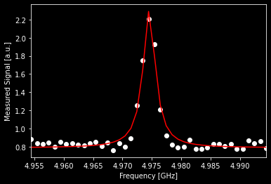

```python
plt.scatter(frequencies_GHz, np.real(sweep_values), color='white')
plt.plot(frequencies_GHz, y_fit, color='red')
plt.xlim([min(frequencies_GHz), max(frequencies_GHz)])

plt.xlabel("Frequency [GHz]")
plt.ylabel("Measured Signal [a.u.]")
plt.show()
```

## Qiskit Pulse - Dispersive Shift

```python
 # Create the schedules for 0 and 1
schedule_0 = pulse.Schedule(name='0')
schedule_0 += measure

schedule_1 = pulse.Schedule(name='1')
schedule_1 += x_pulse
schedule_1 += measure << schedule_1.duration
```

## Qiskit Pulse - Dispersive Shift

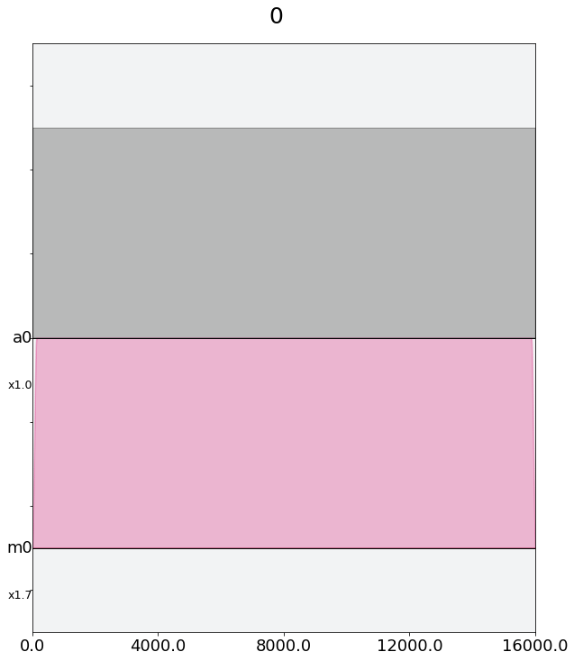

```python
schedule_0.draw()
```

## Qiskit Pulse - Dispersive Shift

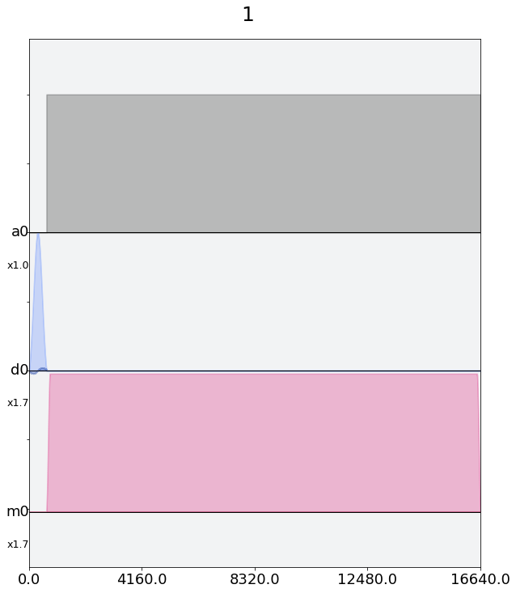

```python
schedule_1.draw()
```

## Qiskit Pulse - Dispersive Shift

```python
frequency_span_Hz = 320 * kHz
frequency_step_Hz = 8 * kHz

center_frequency_Hz = backend_defaults.meas_freq_est[qubit]
print(f"Qubit {qubit} has an estimated readout frequency of {center_frequency_Hz / GHz} GHz.")
frequency_min = center_frequency_Hz - frequency_span_Hz / 2
frequency_max = center_frequency_Hz + frequency_span_Hz / 2
frequencies_GHz = np.arange(frequency_min / GHz,
                            frequency_max / GHz,
                            frequency_step_Hz / GHz)

print(f"The sweep will go from {frequency_min / GHz} GHz to {frequency_max / GHz} GHz\
      in steps of {frequency_step_Hz / MHz} MHz.")
```

```
Qubit 0 has an estimated readout frequency of 6.993427855 GHz.
The sweep will go from 6.993267855 GHz to 6.993587855 GHz      in steps of 0.008 MHz.
```

## Qiskit Pulse - Dispersive Shift

```python
num_shots_per_frequency = 2048

frequencies_Hz = frequencies_GHz*GHz
schedule_los = [{meas_chan: freq} for freq in frequencies_Hz]

cavity_sweep_0 = assemble(schedule_0,
                               backend=backend,
                               meas_level=1,
                               meas_return='avg',
                               shots=num_shots_per_frequency,
                               schedule_los=schedule_los)

cavity_sweep_1 = assemble(schedule_1,
                               backend=backend,
                               meas_level=1,
                               meas_return='avg',
                               shots=num_shots_per_frequency,
                               schedule_los=schedule_los)
```

```python
# RUN the job on a real device
#job_0 = backend.run(cavity_sweep_0)
#job_monitor(job_0)
#job_0.error_message()

#job_1 = backend.run(cavity_sweep_1)
#job_monitor(job_1)
#job_1.error_message()

# OR retreive result from previous run
job_0 = backend.retrieve_job('5efa5b447c0d6800137fff1c')
job_1 = backend.retrieve_job('5efa6b2720eee10013be46b4')

cavity_sweep_0_results = job_0.result()
cavity_sweep_1_results = job_1.result()
```

## Qiskit Pulse - Dispersive Shift

```python
scale_factor = 1e-14

sweep_values_0 = []
for i in range(len(cavity_sweep_0_results.results)):
    res_0 = cavity_sweep_0_results.get_memory(i)*scale_factor
    sweep_values_0.append(res_0[qubit])

sweep_values_1 = []
for i in range(len(cavity_sweep_1_results.results)):
    res_1 = cavity_sweep_1_results.get_memory(i)*scale_factor
    sweep_values_1.append(res_1[qubit])

plotx = frequencies_Hz/kHz
ploty_0 = np.abs(sweep_values_0)
ploty_1 = np.abs(sweep_values_1)
```

## Qiskit Pulse - Dispersive Shift

$$ H_{\rm eff} = \left(\omega_r + \frac{g^2}{\Delta}\sigma_z\right)a^\dagger a - \frac{1}{2}\left(\omega_q -\frac{g^2}{\Delta}\right) \sigma_z $$

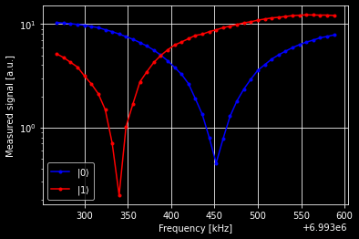

```python
plt.plot(plotx, ploty_0, color='blue', marker='.') # plot real part of sweep values
plt.plot(plotx, ploty_1, color='red', marker='.') # plot real part of sweep values
plt.legend([r'$\vert0\rangle$', r'$\vert1\rangle$'])

plt.grid()
plt.xlabel("Frequency [kHz]")
plt.ylabel("Measured signal [a.u.]")
plt.yscale('log')
plt.show()
```

# On to Exercise 1...